# Reproducible Research W2 Assignment

Henrik Karlsson

2017-02-01

### Loading the packages that will be used

```r
library(dplyr)
```

```r
library(ggplot2)
library(gridExtra)
library(lubridate)
```

## Reading data

Task: 1. Load the data (i.e. 𝚛𝚎𝚊𝚍.𝚌𝚜𝚟()) 2. Process/transform the data (if necessary) into a format suitable for your analysis

Reading data and quick way of getting to know the data

```r
setwd("~/Google Drive/R/Coursera/Reproducible Research/W2 Assignment")

d <- read.csv(file = "activity.csv", header = TRUE, sep = ",")

str(d)
```

```
## 'data.frame':    17568 obs. of  3 variables:
##  $ steps   : int  NA NA NA NA NA NA NA NA NA NA ...
##  $ date    : Factor w/ 61 levels "2012-10-01","2012-10-02",..: 1 1 1 1 1 1 1 1 1 1 ...
##  $ interval: int  0 5 10 15 20 25 30 35 40 45 ...
```

```r
summary(d$steps)
```

```
##    Min. 1st Qu.  Median    Mean 3rd Qu.    Max.    NA's
##    0.00    0.00    0.00   37.38   12.00  806.00    2304
```

## What is mean total number of steps taken per day?

Task: 1. Calculate the total number of steps taken per day 2. If you do not understand the difference between a histogram and a barplot, research the difference between them. Make a histogram of the total number of steps taken each day 3. Calculate and report the mean and median of the total number of steps taken per day

For this part, I’m ignoring the NA in the data.

```r
steps_per_day <- group_by(d, date) %>%
        summarise(steps = sum(steps, na.rm = TRUE))
```

### Histogram of the steps per day

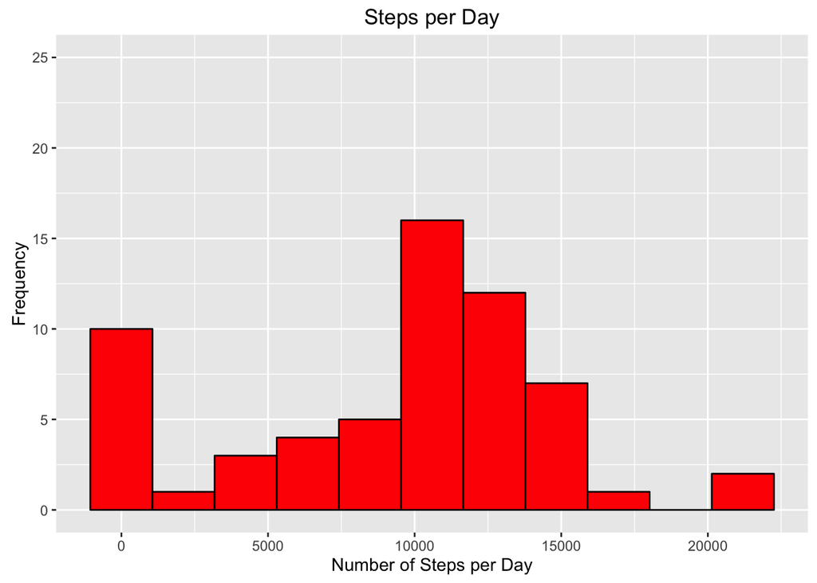

```r
g <- ggplot(data = steps_per_day, aes(steps)) +
        geom_histogram(bins = 11, fill = "red", color = "black") +
        ylim(0,25) +
        labs(title = "Steps per Day") +
        labs(x = "Number of Steps per Day") +
        labs(y = "Frequency")

print(g)
```

### Mean and median of steps per day

```r
summary(steps_per_day$steps)[3:4]
```

```
## Median   Mean
##  10400   9354
```

# What is the average daily activity pattern?

1. Make a time series plot (i.e. 𝚝𝚢𝚙𝚎 = “𝚕”) of the 5-minute interval (x-axis) and the average number of steps taken, averaged across all days (y-axis)
2. Which 5-minute interval, on average across all the days in the dataset, contains the maximum number of steps?

```r
daily_pattern <- group_by(d, interval) %>%
        summarise(steps_interval = mean(steps, na.rm = TRUE))
```

I start this task in the reversed order, finding the highest value first.

```r
y_max <- max(daily_pattern$steps_interval)
x_y_max <- daily_pattern$interval[daily_pattern$steps_interval == y_max]

print(round(c(x_y_max, y_max)),0)
```

```
## [1] 835 206
```

Plotting the graph

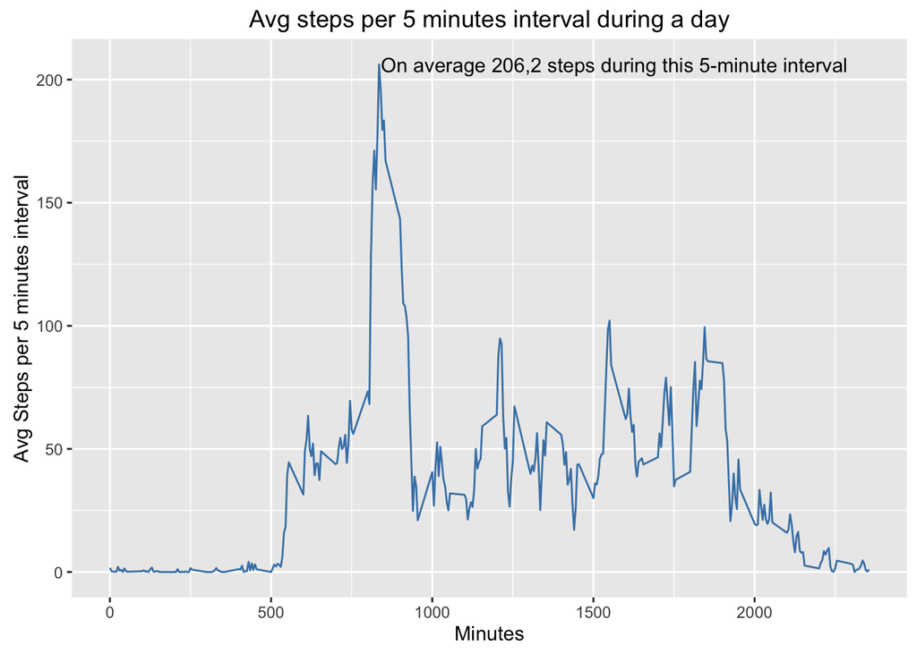

```r
ggplot(data = daily_pattern, aes(x = interval, y = steps_interval)) +
        geom_line(color = "steelblue") +
        labs(title = "Avg steps per 5 minutes interval during a day") +
        labs(y = "Avg Steps per 5 minutes interval") +
        labs(x = "Minutes") +
        annotate("text", y = y_max, x = (x_y_max + 730), label = "On average 206,2 steps during this 5-minute interval")
```

## Imputing missing values

Task:

1. Calculate and report the total number of missing values in the data set
2. Devisa a strategy for filling all of the missing values in the dataset.
3. Create a new dataset that is equal to the original dataset but with the missing data filled in.
4. Make a histogram of the total number of steps taken each day and Calculate and report the **mean** and **median** total number of steps taken per day. Do these values differ from the estimates from the first part of the assignment? What is the impact of imputing missing data on the estimates of the total daily number of steps?

Number of missing values in data

```r
for(i in 1:length(d)){
        print(names(d)[i], quote = FALSE)
        print(table(is.na(d[,i])))
}
```

```
## [1] steps
##
## FALSE  TRUE
## 15264  2304
## [1] date
##
## FALSE
## 17568
## [1] interval
##
## FALSE
## 17568
```

We can see that steps is the only column with missing values and there are 2304 of them.

### Strategy for filling all missing data

I will insert the average number of steps for the specific 5-minute interval in all missing intervals.

I start by filtering out all rows with missing values and remove all rows with missing values from my dataset d.

```r
miss <- filter(d, is.na(steps))

d_clean <- filter(d, !is.na(steps))
```

Then I: 1. join my missing data with my average data per 5-minute interval 2. Remove the column with NA’s (steps) and rename my avg steps per 5-minute interval to “steps”. 3. Bind rows with the imputated data set and my cleaned dataset.

```r
imp <- left_join(x = miss, y = daily_pattern, by = "interval")%>%
        select(-steps, steps = steps_interval) %>%
        bind_rows(d_clean)
```

## Make new histogram and compute mean and median

First I need to aggregate the data to a daily level

```r
steps_per_day_imp <- group_by(imp, date) %>%
        summarise(steps = sum(steps))
```

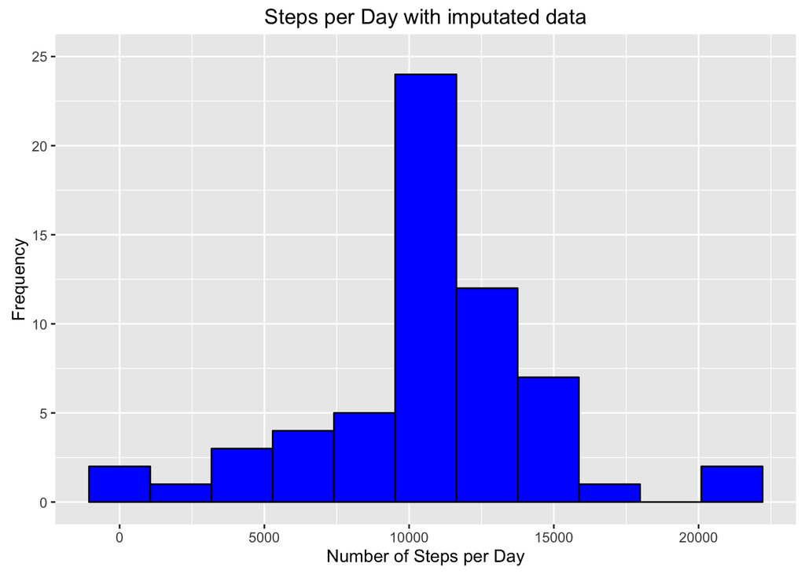

```r
ig <- ggplot(data = steps_per_day_imp, aes(steps)) +
        geom_histogram(bins = 11, fill = "blue", color = "black") +
        ylim(0,25)+
        labs(title = "Steps per Day with imputated data") +
        labs(x = "Number of Steps per Day") +
        labs(y = "Frequency")

print(ig)
```

### Mean and Median of Daily steps

```r
summary(steps_per_day_imp$steps)[3:4]
```

```
## Median   Mean
##  10770  10770
```

Compare histogram with and without imputaded data

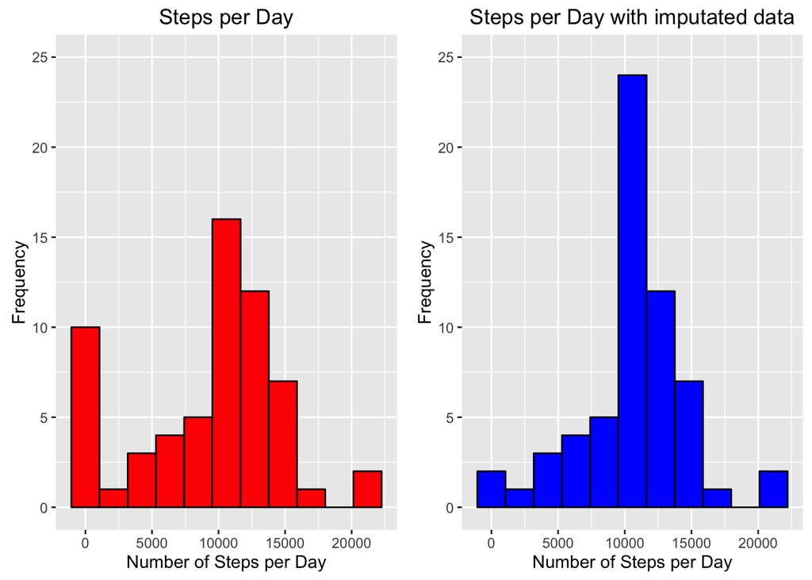

```r
print(grid.arrange(g, ig, nrow = 1, ncol = 2))
```

## Impact of using imputations in data

We can see that adding the average for all the missing data points affects the data so the median is now equal to the mean. Also the number of days (frequency of days) in the average of number of steps per day have increased alot.

## Are there difference in patterns between weekdays and weekends?

1. Create a new factor variable in the dataset with two levels – “weekday” and “weekend” indicating whether a given date is a weekday or weekend day.
2. Make a panel plot containing a time series plot (i.e. 𝚝𝚢𝚙𝚎 = “𝚕”) of the 5-minute interval (x-axis) and the average number of steps taken, averaged across all weekday days or weekend days (y-axis).

### Create factor indicating weekday

```r
d$date <- ymd(as.character(d$date))

d$weekday <- weekdays(d$date)

d$weekday[d$weekday == "Måndag"] <- "Weekday"
d$weekday[d$weekday == "Tisdag"] <- "Weekday"
d$weekday[d$weekday == "Onsdag"] <- "Weekday"
d$weekday[d$weekday == "Torsdag"] <- "Weekday"
d$weekday[d$weekday == "Fredag"] <- "Weekday"
d$weekday[d$weekday == "Lördag"] <- "Weekend"
d$weekday[d$weekday == "Söndag"] <- "Weekend"

table(d$weekday)
```

```
##
## Weekday Weekend
##   12960    4608
```

### Compare weekday to weekends

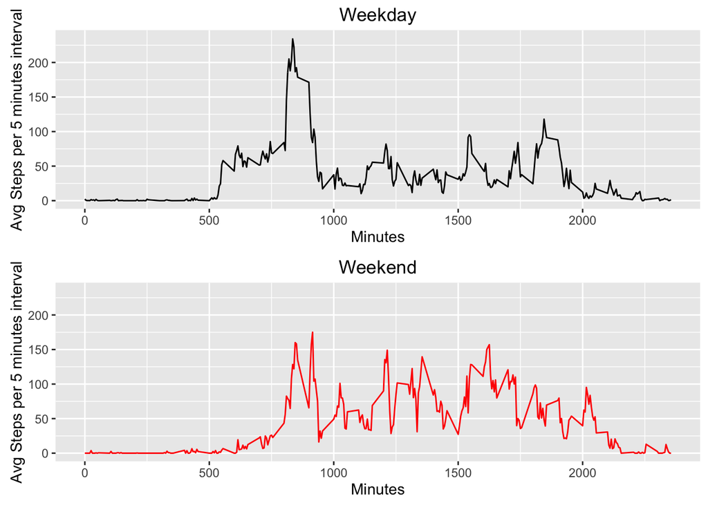

```r
wd <- filter(d, weekday == "Weekday")
we <- filter(d, weekday == "Weekend")

wd <- group_by(wd, interval) %>%
        summarise(steps = mean(steps, na.rm = TRUE))


we <- group_by(we, interval) %>%
        summarise(steps = mean(steps, na.rm = TRUE))

wd_plot <- ggplot(data = wd, aes(x = interval, y = steps)) +
        geom_line(color = "black") +
        ylim(0,235) +
        labs(title = "Weekday") +
        labs(y = "Avg Steps per 5 minutes interval") +
        labs(x = "Minutes")

we_plot <- ggplot(data = we, aes(x = interval, y = steps)) +
        geom_line(color = "red") +
        ylim(0,235) +
        labs(title = "Weekend") +
        labs(y = "Avg Steps per 5 minutes interval") +
        labs(x = "Minutes")

print(grid.arrange(wd_plot, we_plot, nrow = 2, ncol = 1))
```